# pm566 hw2

Author

Sabrina (Hsi-Hsuan) Yang

```r
library(data.table)
library(leaflet)
library(tidyverse)
library(dplyr)
library(ggplot2)
library(R.utils)
download.file("https://raw.githubusercontent.com/USCbiostats/data-science-data/master/01_chs/chs_individual.csv", destfile= "individual.csv")
download.file("https://raw.githubusercontent.com/USCbiostats/data-science-data/master/01_chs/chs_regional.csv", destfile = "regional.csv")
individual <- data.table::fread("individual.csv")
regional <- data.table::fread("regional.csv")
#merge data
chscombination<-merge(x=individual, y=regional, by.x="townname", by.y="townname", all.x=TRUE, all.y=TRUE)
#print sample of the data
chscombination[1:5,.(townname, pm25_so4, bmi)]
```

```
   townname pm25_so4      bmi
1:   Alpine     1.73 15.33749
2:   Alpine     1.73 15.93183
3:   Alpine     1.73 19.38649
4:   Alpine     1.73 16.63283
5:   Alpine     1.73 15.75758
```

```r
#missing values: replace with male and hispanic
chscombination[,bminew:=fcoalesce(bmi, mean(bmi, na.rm=TRUE)), by=.(male, hispanic)]
chscombination[,fevnew:=fcoalesce(fev, mean(fev, na.rm=TRUE)), by=.(male, hispanic)]
chscombination[,pm25_massnew:=fcoalesce(pm25_mass, mean(fvc, na.rm=TRUE)), by=.(male, hispanic)]
summary(chscombination$bminew)
```

```
   Min. 1st Qu.  Median    Mean 3rd Qu.    Max.
  11.30   15.96   17.81   18.50   19.99   41.27
```

```r
summary(chscombination$fevnew)
```

```
   Min. 1st Qu.  Median    Mean 3rd Qu.    Max.
  984.8  1827.6  2016.4  2030.1  2223.6  3323.7
```

```r
summary(chscombination$pm25_massnew)
```

```
   Min. 1st Qu.  Median    Mean 3rd Qu.    Max.
  5.960   7.615  10.545  14.362  20.988  29.970
```

```r
table(chscombination$bminew)
```

[output not shown]

[output cut: 299 more lines]

[output not shown]

```r
table(chscombination$fevnew)
```

[output not shown]

[output cut: 487 more lines]

[output not shown]

```r
table(chscombination$pm25_massnew)
```

```
 5.96  7.19  7.48  7.66   8.5  8.74 12.35 19.12 20.52 22.39 22.46 29.97
  100   100   100   100   100   100   100   100   100   100   100   100
```

No duplicates after the merge. Total of 1200 rows and 49 variables.

```r
#new bmi categorical variable
chscombination$obesity_level<-ifelse(chscombination$bminew > 24 , "obese",
                  ifelse(chscombination$bminew >= 22 & chscombination$bmi <= 24, "overweight",
                  ifelse(chscombination$bminew >= 14 & chscombination$bmi <22, "normal", "underweight" )))
summary(chscombination$bminew)
```

```
   Min. 1st Qu.  Median    Mean 3rd Qu.    Max.
  11.30   15.96   17.81   18.50   19.99   41.27
```

```r
table(chscombination$obesity_level)
```

```
     normal       obese  overweight underweight
        886         103          87          35
```

```r
#create smoke_gas_exposure variable and 4 categories
chscombination %>% group_by(smoke, gasstove) %>% count()
```

```
# A tibble: 9 × 3
# Groups:   smoke, gasstove [9]
  smoke gasstove     n
  <int>    <int> <int>
1     0        0   214
2     0        1   739
3     0       NA    17
4     1        0    36
5     1        1   151
6     1       NA     3
7    NA        0     5
8    NA        1    22
9    NA       NA    13
```

```r
chscombination<-chscombination %>%
  mutate(smoke_gas_exposure= case_when(smoke==0 & gasstove==0~"no exposure",
                                       smoke==1 & gasstove==0~"gas exposure only",
                                       smoke==0 & gasstove==1~"smoke exposure only",
                                       smoke==1 & gasstove==1~"smoke gas exposure"))
summary(chscombination$smoke)
```

```
   Min. 1st Qu.  Median    Mean 3rd Qu.    Max.    NA's
 0.0000  0.0000  0.0000  0.1638  0.0000  1.0000      40
```

```r
summary(chscombination$gasstove)
```

```
   Min. 1st Qu.  Median    Mean 3rd Qu.    Max.    NA's
 0.0000  1.0000  1.0000  0.7815  1.0000  1.0000      33
```

```r
table(chscombination$smoke_gas_exposure)
```

```
  gas exposure only         no exposure smoke exposure only  smoke gas exposure
                 36                 214                 739                 151
```

Created 4 categories: no exposure, gas exposure only, smoke exposure only, and smoke gas exposure. 40 observations are missing for smoke variable, and 33 observations are missing for gasstove variable.

```r
#summary tables showing the average (or proportion, if binary) and sd of “Forced expiratory volume in 1 second (ml)” and asthma indicator by town, sex, obesity level, and “smoke_gas_exposure.”
#townname
chscombination %>% group_by(townname) %>%
  summarize(
    avg_fev1 = mean(fev, na.rm = TRUE),
    sd_fev1 = sd(fev, na.rm = TRUE),
    avg_asthma = mean(asthma, na.rm = TRUE),
    sd_asthma = sd(asthma, na.rm = TRUE))
```

```
# A tibble: 12 × 5
   townname      avg_fev1 sd_fev1 avg_asthma sd_asthma
   <chr>            <dbl>   <dbl>      <dbl>     <dbl>
 1 Alpine           2089.    298.      0.113     0.319
 2 Atascadero       2079.    332.      0.255     0.438
 3 Lake Elsinore    2040.    318.      0.126     0.334
 4 Lake Gregory     2092.    338.      0.152     0.360
 5 Lancaster        2003.    337.      0.165     0.373
 6 Lompoc           2038.    367.      0.113     0.319
 7 Long Beach       1984.    331.      0.135     0.344
 8 Mira Loma        1985.    337.      0.158     0.367
 9 Riverside        1986.    290.      0.11      0.314
10 San Dimas        2028.    322.      0.172     0.379
11 Santa Maria      2023.    330.      0.134     0.342
12 Upland           2027.    357.      0.121     0.328
```

```r
#sex
chscombination<-chscombination %>% mutate(sex=case_when(male == 0 ~ "Female",
                                               male == 1 ~ "Male"))
chscombination %>% group_by(sex) %>%
    summarize(
    avg_fev1 = mean(fev, na.rm = TRUE),
    sd_fev1 = sd(fev, na.rm = TRUE),
    avg_asthma = mean(asthma, na.rm = TRUE),
    sd_asthma = sd(asthma, na.rm = TRUE))
```

```
# A tibble: 2 × 5
  sex    avg_fev1 sd_fev1 avg_asthma sd_asthma
  <chr>     <dbl>   <dbl>      <dbl>     <dbl>
1 Female    1959.    327.      0.121     0.326
2 Male      2104.    318.      0.173     0.378
```

```r
#obesity
chscombination %>% group_by(obesity_level) %>%
  summarize(
    avg_fev1 = mean(fev, na.rm = TRUE),
    sd_fev1 = sd(fev, na.rm = TRUE),
    avg_asthma = mean(asthma, na.rm = TRUE),
    sd_asthma = sd(asthma, na.rm = TRUE))
```

```
# A tibble: 5 × 5
  obesity_level avg_fev1 sd_fev1 avg_asthma sd_asthma
  <chr>            <dbl>   <dbl>      <dbl>     <dbl>
1 normal           1998.    309.     0.141      0.348
2 obese            2269.    326.     0.21       0.409
3 overweight       2224.    317.     0.165      0.373
4 underweight      1687.    300.     0.0857     0.284
5 <NA>              NaN      NA      0.131      0.339
```

```r
#smoke gas exposure
chscombination %>% group_by(smoke_gas_exposure) %>%
  summarize(
    avg_fev1 = mean(fev, na.rm = TRUE),
    sd_fev1 = sd(fev, na.rm = TRUE),
    avg_asthma = mean(asthma, na.rm = TRUE),
    sd_asthma = sd(asthma, na.rm = TRUE))
```

```
# A tibble: 5 × 5
  smoke_gas_exposure  avg_fev1 sd_fev1 avg_asthma sd_asthma
  <chr>                  <dbl>   <dbl>      <dbl>     <dbl>
1 gas exposure only      2064.    333.      0.171     0.382
2 no exposure            2060.    343.      0.148     0.356
3 smoke exposure only    2026.    328.      0.148     0.355
4 smoke gas exposure     2020.    313.      0.130     0.338
5 <NA>                   2000.    365.      0.149     0.360
```

```r
#take a look at the key variables
dim(chscombination)
```

```
[1] 1200   55
```

```r
head(chscombination)
```

```
   townname sid male race hispanic    agepft height weight      bmi asthma
1:   Alpine 835    0    W        0 10.099932    143     69 15.33749      0
2:   Alpine 838    0    O        1  9.486653    133     62 15.93183      0
3:   Alpine 839    0    M        1 10.053388    142     86 19.38649      0
4:   Alpine 840    0    W        0  9.965777    146     78 16.63283      0
5:   Alpine 841    1    W        1 10.548939    150     78 15.75758      0
6:   Alpine 842    1    M        1  9.489391    139     65 15.29189      0
   active_asthma father_asthma mother_asthma wheeze hayfever allergy
1:             0             0             0      0        0       1
2:             0             0             0      0        0       0
3:             0             0             1      1        1       1
4:             0             0             0      0        0       0
5:             0             0             0      0        0       0
6:             0             0             0      1        0       0
   educ_parent smoke pets gasstove      fev      fvc     mmef pm25_mass
```

[output cut: 34 more lines]

```r
tail(chscombination)
```

```
   townname  sid male race hispanic    agepft height weight      bmi asthma
1:   Upland 1866    0    O        1  9.806982    139     60 14.11559      0
2:   Upland 1867    0    M        1  9.618070    140     71 16.46568      0
3:   Upland 2031    1    W        0  9.798768    135     83 20.70084      0
4:   Upland 2032    1    W        0  9.549624    137     59 14.28855      0
5:   Upland 2033    0    M        0 10.121834    130     67 18.02044      0
6:   Upland 2053    0    W        0        NA     NA     NA       NA      0
   active_asthma father_asthma mother_asthma wheeze hayfever allergy
1:             0            NA             0      0       NA      NA
2:             0             1             0      0        0       0
3:             0             0             0      1        0       1
4:             0             0             1      1        1       1
5:             1             0             0      1        1       0
6:             0             0             0      0        0       0
   educ_parent smoke pets gasstove      fev      fvc     mmef pm25_mass
```

[output cut: 34 more lines]

```r
str(chscombination)
```

```
Classes 'data.table' and 'data.frame':  1200 obs. of  55 variables:
 $ townname          : chr  "Alpine" "Alpine" "Alpine" "Alpine" ...
 $ sid               : int  835 838 839 840 841 842 843 844 847 849 ...
 $ male              : int  0 0 0 0 1 1 1 1 1 1 ...
 $ race              : chr  "W" "O" "M" "W" ...
 $ hispanic          : int  0 1 1 0 1 1 0 1 0 0 ...
 $ agepft            : num  10.1 9.49 10.05 9.97 10.55 ...
 $ height            : int  143 133 142 146 150 139 149 143 137 147 ...
 $ weight            : int  69 62 86 78 78 65 98 65 69 112 ...
 $ bmi               : num  15.3 15.9 19.4 16.6 15.8 ...
 $ asthma            : int  0 0 0 0 0 0 0 NA 0 0 ...
 $ active_asthma     : int  0 0 0 0 0 0 0 0 0 0 ...
 $ father_asthma     : int  0 0 0 0 0 0 0 NA 0 1 ...
 $ mother_asthma     : int  0 0 1 0 0 0 0 NA 0 0 ...
 $ wheeze            : int  0 0 1 0 0 1 1 NA 0 1 ...
```

[output cut: 43 more lines]

```r
#correlation between bmi and fev
cor(chscombination$bminew, chscombination$fevnew, use="complete")
```

```
[1] 0.357112
```

```r
#correlation between pm2.5_mass and fev
cor(chscombination$pm25_massnew, chscombination$fevnew, use="complete")
```

```
[1] -0.07341317
```

```r
summary(chscombination$bminew)
```

```
   Min. 1st Qu.  Median    Mean 3rd Qu.    Max.
  11.30   15.96   17.81   18.50   19.99   41.27
```

```r
summary(chscombination$fevnew)
```

```
   Min. 1st Qu.  Median    Mean 3rd Qu.    Max.
  984.8  1827.6  2016.4  2030.1  2223.6  3323.7
```

```r
summary(chscombination$smoke_gas_exposure)
```

```
   Length     Class      Mode
     1200 character character
```

```r
summary(chscombination$pm25_massnew)
```

```
   Min. 1st Qu.  Median    Mean 3rd Qu.    Max.
  5.960   7.615  10.545  14.362  20.988  29.970
```

There are 1200 observations and 55 variables in the dataset. The results show that there is a slight positive correlation (0.357) between bmi and fev, while a slight negative correlation (-0.073) between pm2.5 mass level and fev.

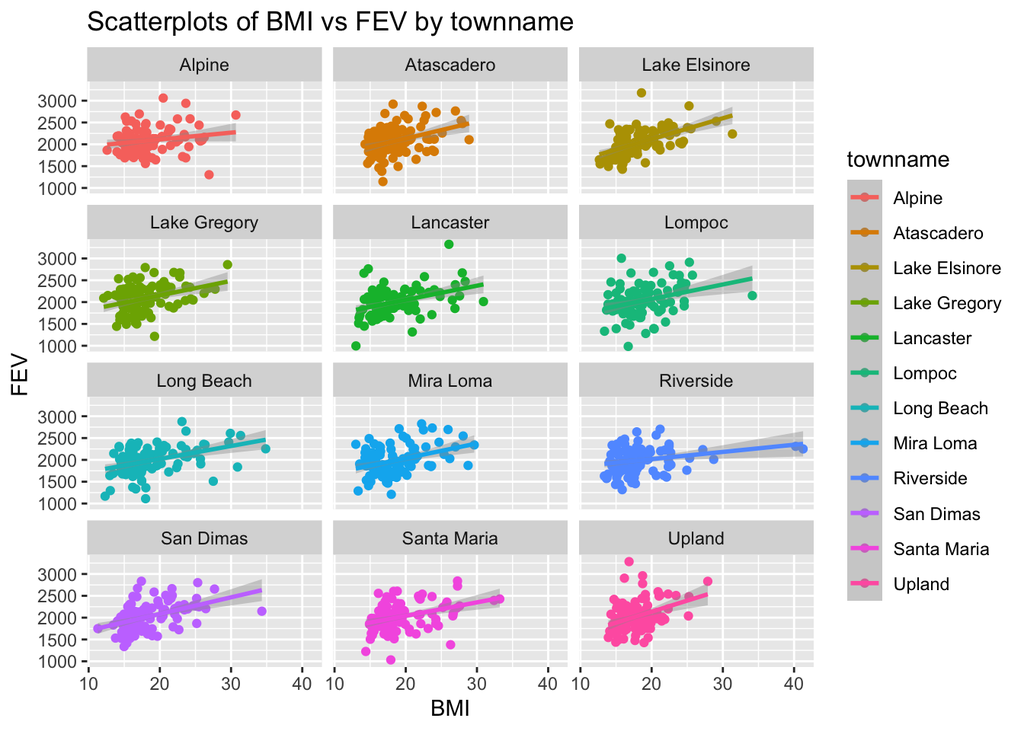

```r
#Facet plot showing scatterplots with regression lines of BMI vs FEV by “townname”
chscombination %>%
  filter(!(townname %in% NA)) %>%
  ggplot(mapping = aes(bminew, fevnew, color=townname))+
  geom_point()+
  stat_smooth(method=lm)+
   facet_wrap(~townname, nrow=4)+
  labs(title="Scatterplots of BMI vs FEV by townname", x="BMI", y="FEV")
```

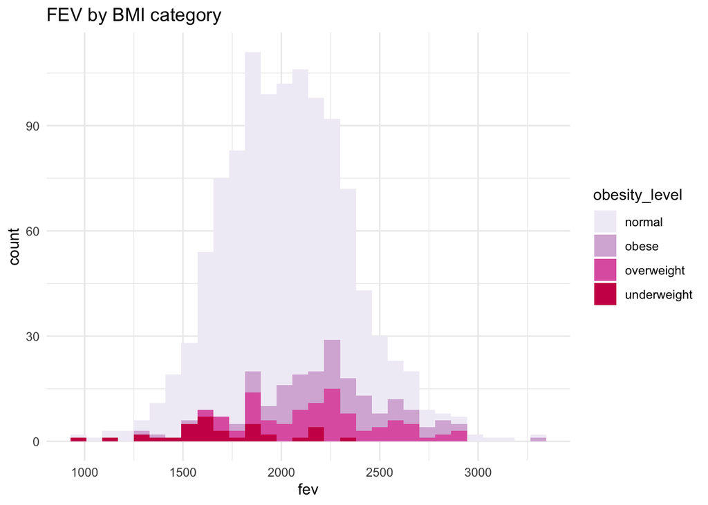

```r
#Stacked histograms of FEV by BMI category
chscombination %>%
  filter(!(obesity_level %in% NA)) %>%
  ggplot()+
  geom_histogram(mapping= aes (fevnew, fill=obesity_level))+
  scale_fill_brewer(palette = "PuRd")+
  labs(title="FEV by BMI category", x="fev", y="count")+
  theme_minimal()
```

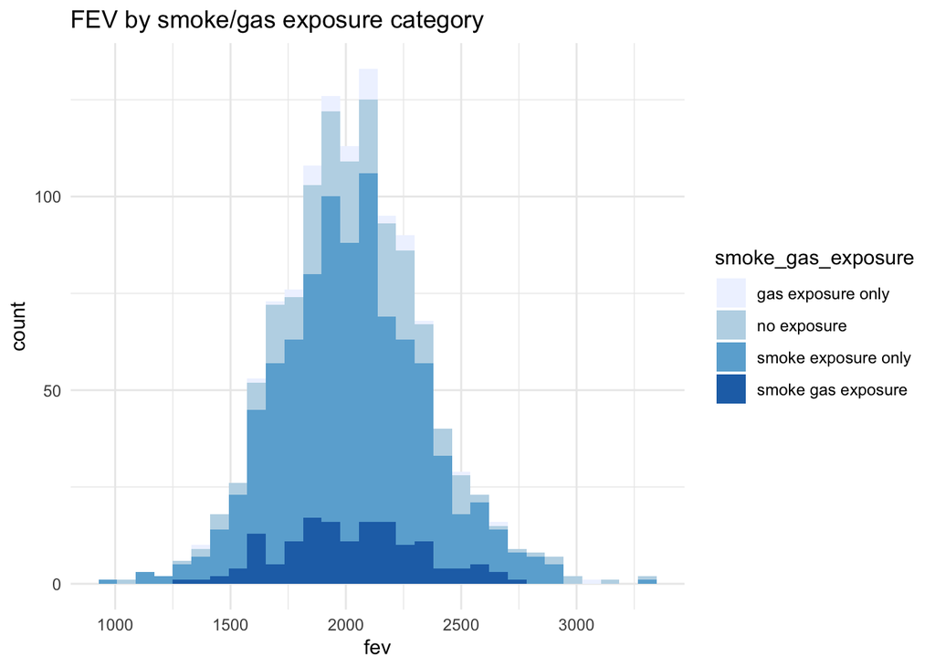

```r
#Stacked histograms of FEV by smoke/gas exposure
chscombination %>%
  filter(!(smoke_gas_exposure %in% NA)) %>%
  ggplot()+
  geom_histogram(mapping= aes (fevnew, fill=smoke_gas_exposure))+
  scale_fill_brewer(palette = "Blues")+
  labs(title="FEV by smoke/gas exposure category", x="fev", y="count")+
  theme_minimal()
```

Based on visualization of the graph: The people with normal bmi are distributed throughout all fev values, and the most count are in 1800-2200 range. Lowest fev falls below 1000, and the highest over 3250.

The highest count falls in the 1800-2200 range for smoke/gas exposure. All categories of smoke/gas exposure besides smoke gas exposure have similar distribution shape among the fev values, while both smoke and gas exposure distributed more evenly compared to the other categories.

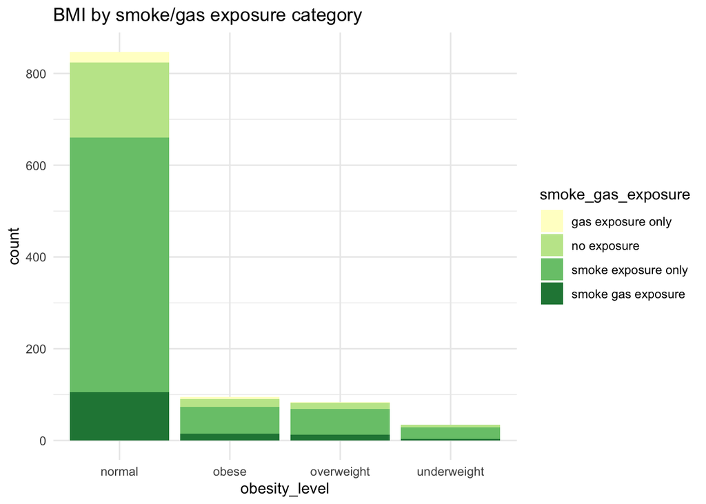

```r
#Barchart of BMI by smoke/gas exposure
chscombination %>%
  filter(!(smoke_gas_exposure %in% NA)) %>%
  filter(!(obesity_level %in% NA)) %>%
  ggplot()+
  geom_bar(mapping= aes (x=obesity_level, fill=smoke_gas_exposure))+
  scale_fill_brewer(palette = "YlGn")+
  labs(title="BMI by smoke/gas exposure category", x="obesity_level", y="count")+
  theme_minimal()
```

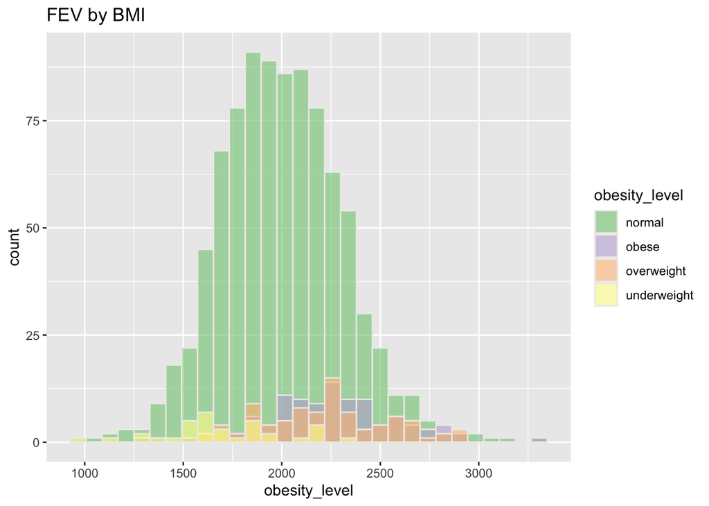

```r
#statistical summary graphs of FEV by BMI and FEV by smoke/gas exposure category
#histogram fev vs bmi
chscombination %>%
  filter(!(obesity_level %in% NA)) %>%
  ggplot( aes(x=fevnew, fill=obesity_level)) +
    geom_histogram( color="#efebe9", alpha=0.6, position = 'identity') +
    scale_fill_brewer(palette = "Accent")+
   labs(title="FEV by BMI", x="obesity_level", y="count")
```

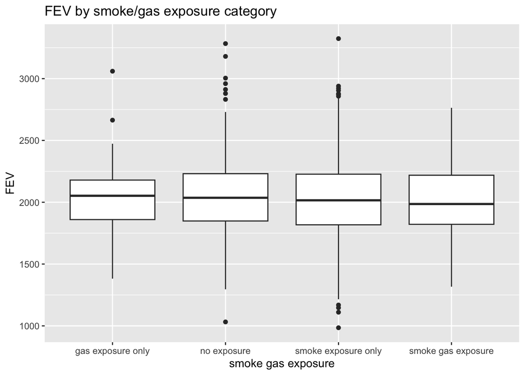

```r
#boxplot fev vs smoke/gas exposure
chscombination %>%
  filter(!(smoke_gas_exposure %in% NA)) %>%
ggplot()+
  geom_boxplot(mapping = aes(y=fevnew, x=smoke_gas_exposure))+
labs(title="FEV by smoke/gas exposure category", x="smoke gas exposure", y="FEV")
```

What is the association between BMI and FEV? According to the stacked histogram and histogram, people with normal bmi are distributed throughout all fev values. People who are in obese or overweight group tend to have higher FEV.

What is the association between smoke/gas exposure and FEV? People who have gas exposure only have the highest mean fev (2064.35) obtained using the mean() function and based on the visualisation of the boxplot. People who have both smoke and gas exposure have fev values distributed more similarly compared to the other categories. People with no exposure and people with smoke exposure only have fev exposure at all ranges.

```r
#A leaflet map showing the concentrations of PM2.5 mass in each of the CHS communities
chsleaflet<-chscombination[!is.na(pm25_mass)]
color_pm25 <- colorNumeric(c('pink', 'blue', 'orange'), domain = unique(chscombination$pm25_mass))
leaflet(chsleaflet) %>%
  addTiles() %>%
  addCircles(lng = ~lon, lat = ~lat,, color=~color_pm25(pm25_mass), opacity=1, fillOpacity = 1, radius=500) %>%
  addLegend('bottomleft', pal=color_pm25, values=chscombination$pm25_mass, title="PM 2.5 mass map", opacity=1)
```

[interactive chart not shown]

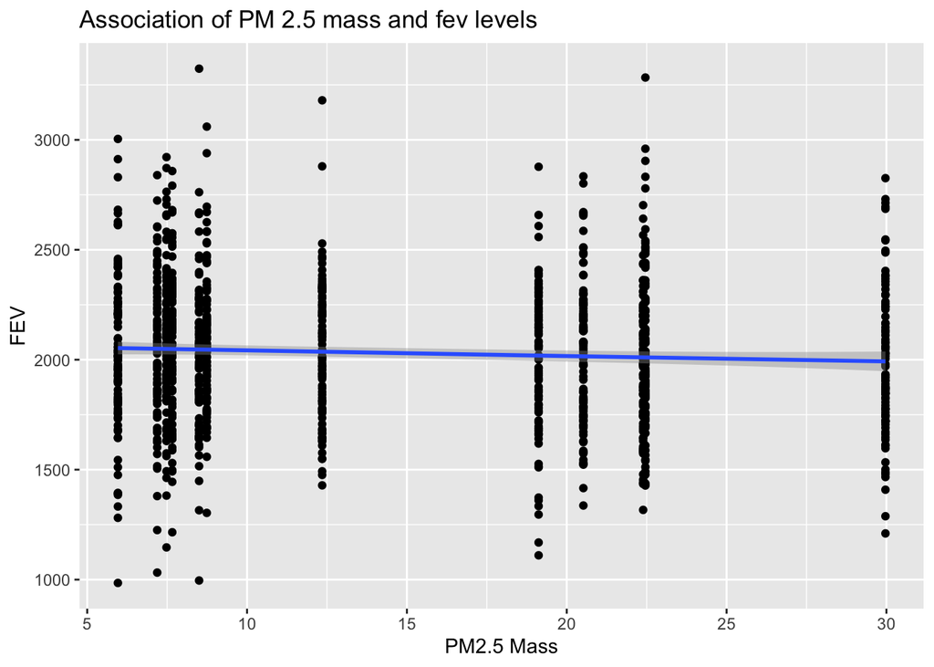

```r
#Choose a visualization to examine whether PM2.5 mass is associated with FEV
chscombination %>%
  filter(!(pm25_mass %in% NA)) %>%
  ggplot(mapping = aes(pm25_mass,fev))+
  geom_point()+
  geom_smooth()+
labs(title="Association of PM 2.5 mass and fev levels", x="PM2.5 Mass", y="FEV")
```

What is the association between PM2.5 exposure and FEV? Based on the correlation line, there doesn’t seem to have an association between pm2.5 mass and fev as not majority of the data lies around the line. Further, it is supported by the correlation value (-0.073) obtained by the cor() function earlier. -0.073 is very closed to 0 meaning that there is no association between pm2.5 mass level and fev.